# CASE 2 - Jhon Heider Domingos Rezende

```r
summary(ur.df(y = na.omit(diff(log(data$sb) - log(stats::lag(data$sb, 1)), lag = 12, differences = 1)), type =  "trend", selectlags = "AIC"))
```

```
##
## ###############################################
## # Augmented Dickey-Fuller Test Unit Root Test #
## ###############################################
##
## Test regression trend
##
##
## Call:
## lm(formula = z.diff ~ z.lag.1 + 1 + tt + z.diff.lag)
##
## Residuals:
##     Min      1Q  Median      3Q     Max
## -6.1014 -0.3314  0.0139  0.2891  5.2649
##
## Coefficients:
##               Estimate Std. Error t value Pr(>|t|)
## (Intercept)  0.0405949  0.1200643   0.338    0.736
## z.lag.1     -1.4948760  0.1020999 -14.641   <2e-16 ***
## tt          -0.0002556  0.0007898  -0.324    0.746
## z.diff.lag   0.0824060  0.0609665   1.352    0.178
## ---
## Signif. codes:  0 '***' 0.001 '**' 0.01 '*' 0.05 '.' 0.1 ' ' 1
##
## Residual standard error: 0.9607 on 257 degrees of freedom
## Multiple R-squared:  0.7015, Adjusted R-squared:  0.6981
## F-statistic: 201.4 on 3 and 257 DF,  p-value: < 2.2e-16
##
##
## Value of test-statistic is: -14.6413 71.4828 107.2107
##
## Critical values for test statistics:
##       1pct  5pct 10pct
## tau3 -3.98 -3.42 -3.13
## phi2  6.15  4.71  4.05
## phi3  8.34  6.30  5.36
```

```r
## Soybeans - Phillips-Perron test for unit root
summary(ur.pp(x = na.omit(diff(log(data$sb) - log(stats::lag(data$sb, 1)), lag = 12, differences = 1)), type = "Z-tau", model = "constant"))
```

```
##
## ##################################
## # Phillips-Perron Unit Root Test #
## ##################################
##
## Test regression with intercept
##
##
## Call:
## lm(formula = y ~ y.l1)
##
## Residuals:
##     Min      1Q  Median      3Q     Max
## -5.9929 -0.3446  0.0100  0.2839  5.3894
##
## Coefficients:
##             Estimate Std. Error t value Pr(>|t|)
## (Intercept)  0.01638    0.06015   0.272    0.786
## y.l1        -0.39393    0.05673  -6.944 3.04e-11 ***
## ---
## Signif. codes:  0 '***' 0.001 '**' 0.01 '*' 0.05 '.' 0.1 ' ' 1
##
## Residual standard error: 0.9737 on 260 degrees of freedom
## Multiple R-squared:  0.1564, Adjusted R-squared:  0.1532
## F-statistic: 48.22 on 1 and 260 DF,  p-value: 3.042e-11
##
##
## Value of test-statistic, type: Z-tau  is: -26.9161
##
##          aux. Z statistics
## Z-tau-mu            0.2944
##
## Critical values for Z statistics:
##                      1pct      5pct     10pct
## critical values -3.456823 -2.872672 -2.572654
```

```r
summary(ur.pp(x = na.omit(diff(log(data$sb) - log(stats::lag(data$sb, 1)), lag = 12, differences = 1)), type = "Z-tau", model = "trend"))
```

```
##
## ##################################
## # Phillips-Perron Unit Root Test #
## ##################################
##
## Test regression with intercept and trend
##
##
## Call:
## lm(formula = y ~ y.l1 + trend)
##
## Residuals:
##     Min      1Q  Median      3Q     Max
## -5.9710 -0.3396 -0.0018  0.2818  5.4090
##
## Coefficients:
##               Estimate Std. Error t value Pr(>|t|)
## (Intercept)  0.0166215  0.0602324   0.276    0.783
## y.l1        -0.3944496  0.0568079  -6.944 3.07e-11 ***
## trend       -0.0004666  0.0007964  -0.586    0.558
## ---
## Signif. codes:  0 '***' 0.001 '**' 0.01 '*' 0.05 '.' 0.1 ' ' 1
##
## Residual standard error: 0.9749 on 259 degrees of freedom
## Multiple R-squared:  0.1576, Adjusted R-squared:  0.1511
## F-statistic: 24.22 on 2 and 259 DF,  p-value: 2.277e-10
##
##
## Value of test-statistic, type: Z-tau  is: -26.9057
##
##            aux. Z statistics
## Z-tau-mu              0.3714
## Z-tau-beta           -0.6328
##
## Critical values for Z statistics:
##                      1pct      5pct     10pct
## critical values -3.996373 -3.428276 -3.137239
```

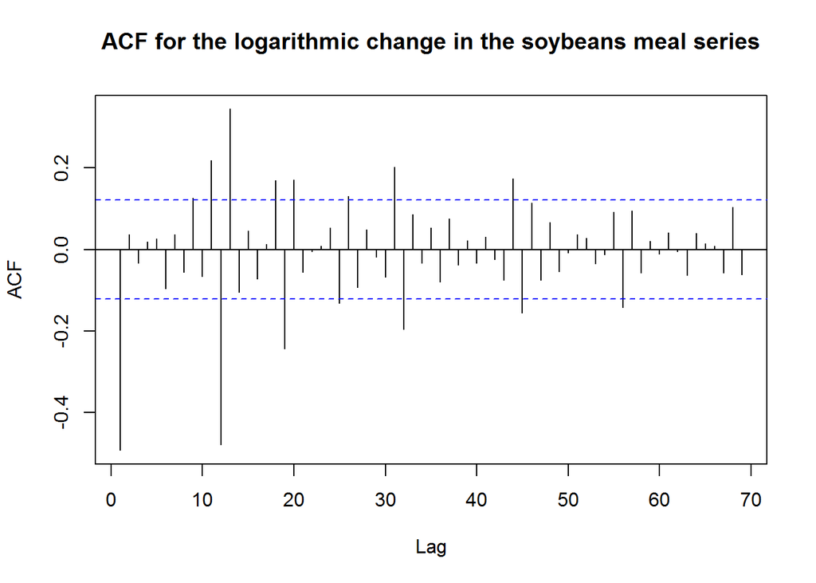

```r
## Soybeans Meal - ACF and PACF
Acf(x = diff(log(data$sb_meal) - log(stats::lag(data$sb_meal, 1)), lag = 12, differences = 1), main = "ACF for the logarithmic change in the soybeans meal series", lag.max = 69, type = 'correlation', plot = TRUE, na.action = na.omit)
```

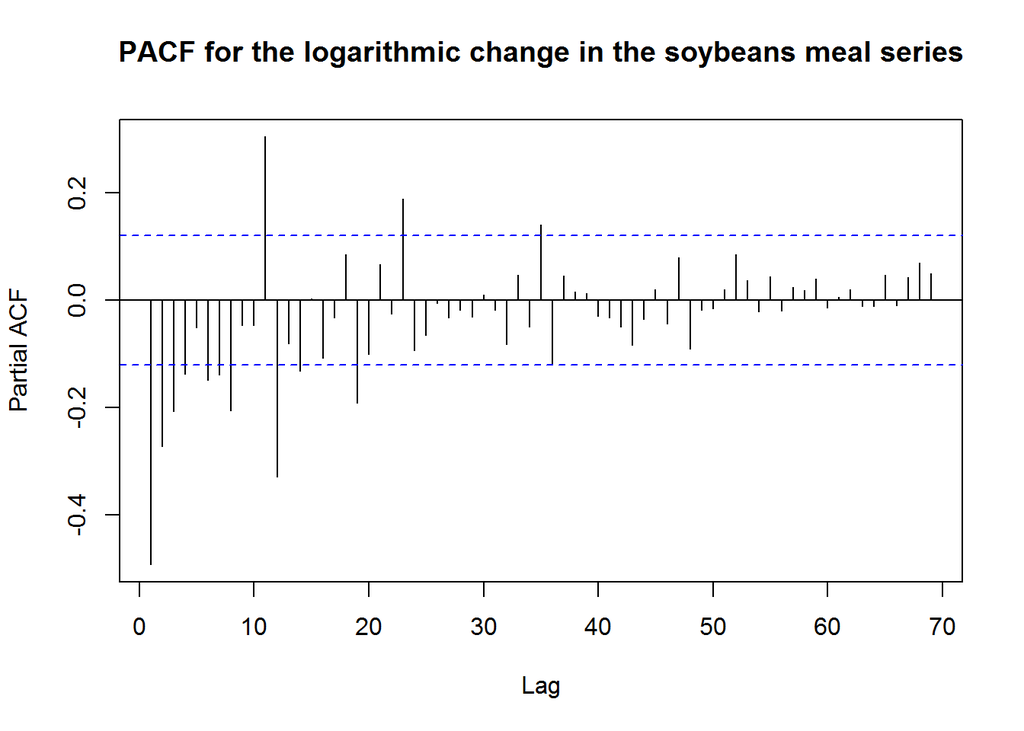

```r
Pacf(x = diff(log(data$sb_meal) - log(stats::lag(data$sb_meal, 1)), lag = 12, differences = 1), lag.max = 69, plot = TRUE,main = "PACF for the logarithmic change in the soybeans meal series", na.action = na.omit) # T/4 - lag max
```

```r
## Soybeans Meal - Augmented Dickey-Fuller Test for unit root
summary(ur.df(y = na.omit(diff(log(data$sb_meal) - log(stats::lag(data$sb_meal, 1)), lag = 12, differences = 1)), type =  "none", selectlags = "AIC"))
```

```
##
## ###############################################
## # Augmented Dickey-Fuller Test Unit Root Test #
## ###############################################
##
## Test regression none
##
##
## Call:
## lm(formula = z.diff ~ z.lag.1 - 1 + z.diff.lag)
##
## Residuals:
##      Min       1Q   Median       3Q      Max
## -1.11614 -0.20580  0.01566  0.20049  1.06110
##
## Coefficients:
##            Estimate Std. Error t value Pr(>|t|)
## z.lag.1    -1.90094    0.10309 -18.440  < 2e-16 ***
## z.diff.lag  0.27285    0.05945   4.589 6.94e-06 ***
## ---
## Signif. codes:  0 '***' 0.001 '**' 0.01 '*' 0.05 '.' 0.1 ' ' 1
##
## Residual standard error: 0.3304 on 259 degrees of freedom
## Multiple R-squared:  0.7659, Adjusted R-squared:  0.7641
## F-statistic: 423.7 on 2 and 259 DF,  p-value: < 2.2e-16
##
##
## Value of test-statistic is: -18.4404
##
## Critical values for test statistics:
##       1pct  5pct 10pct
## tau1 -2.58 -1.95 -1.62
```

```r
summary(ur.df(y = na.omit(diff(log(data$sb_meal) - log(stats::lag(data$sb_meal, 1)), lag = 12, differences = 1)), type =  "drift", selectlags = "AIC"))
```

```
##
## ###############################################
## # Augmented Dickey-Fuller Test Unit Root Test #
## ###############################################
##
## Test regression drift
##
##
## Call:
## lm(formula = z.diff ~ z.lag.1 + 1 + z.diff.lag)
##
## Residuals:
##      Min       1Q   Median       3Q      Max
## -1.11759 -0.20729  0.01418  0.19902  1.05964
##
## Coefficients:
##              Estimate Std. Error t value Pr(>|t|)
## (Intercept)  0.001467   0.020492   0.072    0.943
## z.lag.1     -1.900979   0.103286 -18.405  < 2e-16 ***
## z.diff.lag   0.272882   0.059570   4.581 7.21e-06 ***
## ---
## Signif. codes:  0 '***' 0.001 '**' 0.01 '*' 0.05 '.' 0.1 ' ' 1
##
## Residual standard error: 0.331 on 258 degrees of freedom
## Multiple R-squared:  0.7659, Adjusted R-squared:  0.7641
## F-statistic: 422.1 on 2 and 258 DF,  p-value: < 2.2e-16
##
##
## Value of test-statistic is: -18.4051 169.3739
##
## Critical values for test statistics:
##       1pct  5pct 10pct
## tau2 -3.44 -2.87 -2.57
## phi1  6.47  4.61  3.79
```

```r
summary(ur.df(y = na.omit(diff(log(data$sb_meal) - log(stats::lag(data$sb_meal, 1)), lag = 12, differences = 1)), type =  "trend", selectlags = "AIC"))
```

```
##
## ###############################################
## # Augmented Dickey-Fuller Test Unit Root Test #
## ###############################################
##
## Test regression trend
##
##
## Call:
## lm(formula = z.diff ~ z.lag.1 + 1 + tt + z.diff.lag)
##
## Residuals:
##      Min       1Q   Median       3Q      Max
## -1.11844 -0.20714  0.01505  0.19851  1.05877
##
## Coefficients:
##               Estimate Std. Error t value Pr(>|t|)
## (Intercept)  2.409e-03  4.142e-02   0.058    0.954
## z.lag.1     -1.901e+00  1.035e-01 -18.369  < 2e-16 ***
## tt          -7.136e-06  2.725e-04  -0.026    0.979
## z.diff.lag   2.729e-01  5.969e-02   4.572 7.51e-06 ***
## ---
## Signif. codes:  0 '***' 0.001 '**' 0.01 '*' 0.05 '.' 0.1 ' ' 1
##
## Residual standard error: 0.3317 on 257 degrees of freedom
## Multiple R-squared:  0.7659, Adjusted R-squared:  0.7632
## F-statistic: 280.3 on 3 and 257 DF,  p-value: < 2.2e-16
##
##
## Value of test-statistic is: -18.3694 112.4788 168.7176
##
## Critical values for test statistics:
##       1pct  5pct 10pct
## tau3 -3.98 -3.42 -3.13
## phi2  6.15  4.71  4.05
## phi3  8.34  6.30  5.36
```

```r
## Soybeans Meal - Phillips-Perron test for unit root
summary(ur.pp(x = na.omit(diff(log(data$sb_meal) - log(stats::lag(data$sb_meal, 1)), lag = 12, differences = 1)), type = "Z-tau", model = "constant"))
```

```
##
## ##################################
## # Phillips-Perron Unit Root Test #
## ##################################
##
## Test regression with intercept
##
##
## Call:
## lm(formula = y ~ y.l1)
##
## Residuals:
##     Min      1Q  Median      3Q     Max
## -1.2487 -0.2126  0.0039  0.1860  1.0701
##
## Coefficients:
##               Estimate Std. Error t value Pr(>|t|)
## (Intercept)  0.0006793  0.0211864   0.032    0.974
## y.l1        -0.4926930  0.0535944  -9.193   <2e-16 ***
## ---
## Signif. codes:  0 '***' 0.001 '**' 0.01 '*' 0.05 '.' 0.1 ' ' 1
##
## Residual standard error: 0.3429 on 260 degrees of freedom
## Multiple R-squared:  0.2453, Adjusted R-squared:  0.2424
## F-statistic: 84.51 on 1 and 260 DF,  p-value: < 2.2e-16
##
##
## Value of test-statistic, type: Z-tau  is: -37.741
##
##          aux. Z statistics
## Z-tau-mu            0.0585
##
## Critical values for Z statistics:
##                      1pct      5pct     10pct
## critical values -3.456823 -2.872672 -2.572654
```

```r
summary(ur.pp(x = na.omit(diff(log(data$sb_meal) - log(stats::lag(data$sb_meal, 1)), lag = 12, differences = 1)), type = "Z-tau", model = "trend"))
```

```
##
## ##################################
## # Phillips-Perron Unit Root Test #
## ##################################
##
## Test regression with intercept and trend
##
##
## Call:
## lm(formula = y ~ y.l1 + trend)
##
## Residuals:
##      Min       1Q   Median       3Q      Max
## -1.24864 -0.21264  0.00388  0.18605  1.07012
##
## Coefficients:
##               Estimate Std. Error t value Pr(>|t|)
## (Intercept)  6.792e-04  2.123e-02   0.032    0.974
## y.l1        -4.927e-01  5.370e-02  -9.175   <2e-16 ***
## trend        1.774e-07  2.807e-04   0.001    0.999
## ---
## Signif. codes:  0 '***' 0.001 '**' 0.01 '*' 0.05 '.' 0.1 ' ' 1
##
## Residual standard error: 0.3436 on 259 degrees of freedom
## Multiple R-squared:  0.2453, Adjusted R-squared:  0.2395
## F-statistic: 42.09 on 2 and 259 DF,  p-value: < 2.2e-16
##
##
## Value of test-statistic, type: Z-tau  is: -37.6539
##
##            aux. Z statistics
## Z-tau-mu              0.0441
## Z-tau-beta           -0.0229
##
## Critical values for Z statistics:
##                      1pct      5pct     10pct
## critical values -3.996373 -3.428276 -3.137239
```

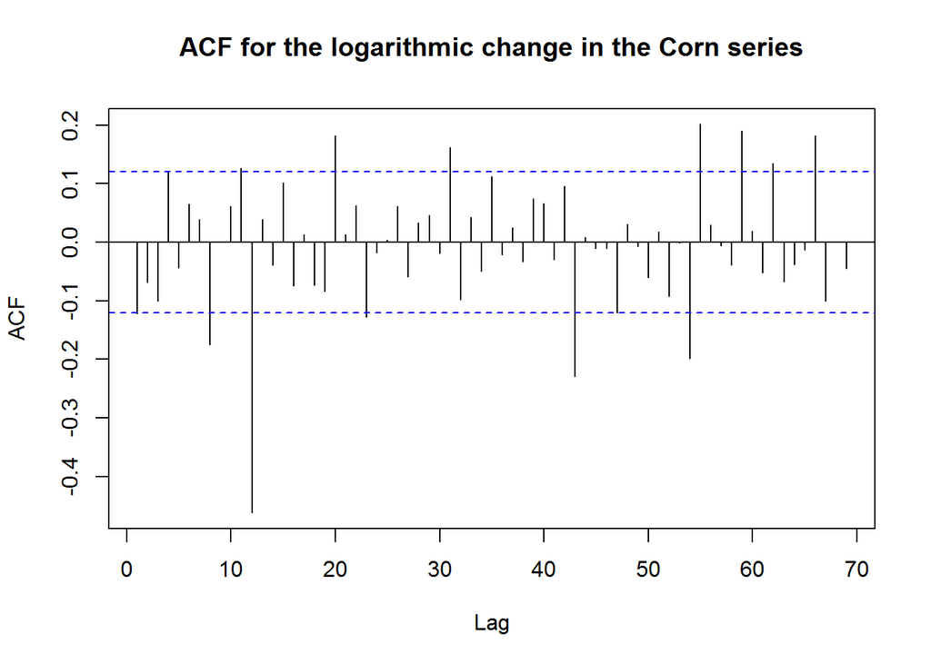

```r
## Corn - ACF and PACF
Acf(x = diff(log(data$corn) - log(stats::lag(data$corn, 1)), lag = 12, differences = 1), lag.max = 69, type = 'correlation', plot = TRUE, main = "ACF for the logarithmic change in the Corn series", na.action = na.omit)
```

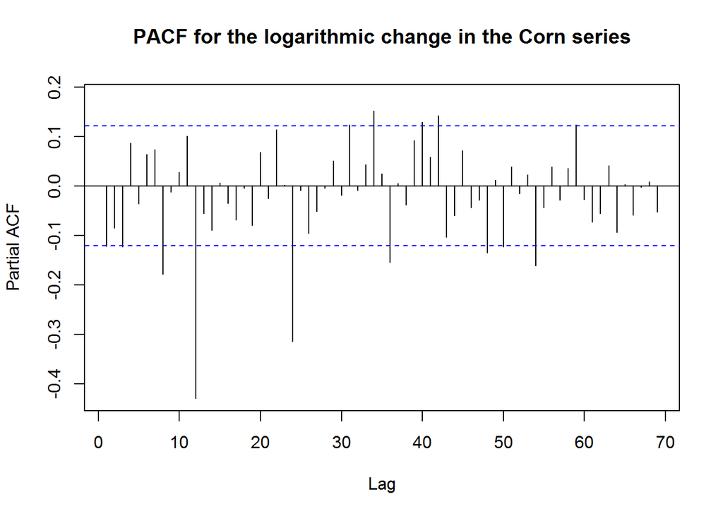

```r
Pacf(x = diff(log(data$corn) - log(stats::lag(data$corn, 1)), lag = 12, differences = 1), lag.max = 69, plot = TRUE, main = "PACF for the logarithmic change in the Corn series", na.action = na.omit) # T/4 - lag max
```

```r
## Corn - Augmented Dickey-Fuller Test for unit root
summary(ur.df(y = na.omit(diff(log(data$corn) - log(stats::lag(data$corn, 1)), lag = 12, differences = 1)), type =  "none", selectlags = "AIC"))
```

```
##
## ###############################################
## # Augmented Dickey-Fuller Test Unit Root Test #
## ###############################################
##
## Test regression none
##
##
## Call:
## lm(formula = z.diff ~ z.lag.1 - 1 + z.diff.lag)
##
## Residuals:
##     Min      1Q  Median      3Q     Max
## -6.2974 -0.5917 -0.0046  0.6485  6.5092
##
## Coefficients:
##            Estimate Std. Error t value Pr(>|t|)
## z.lag.1    -1.21905    0.09250 -13.178   <2e-16 ***
## z.diff.lag  0.08477    0.06162   1.376     0.17
## ---
## Signif. codes:  0 '***' 0.001 '**' 0.01 '*' 0.05 '.' 0.1 ' ' 1
##
## Residual standard error: 1.536 on 259 degrees of freedom
## Multiple R-squared:  0.5652, Adjusted R-squared:  0.5618
## F-statistic: 168.3 on 2 and 259 DF,  p-value: < 2.2e-16
##
##
## Value of test-statistic is: -13.1783
##
## Critical values for test statistics:
##       1pct  5pct 10pct
## tau1 -2.58 -1.95 -1.62
```

```r
summary(ur.df(y = na.omit(diff(log(data$corn) - log(stats::lag(data$corn, 1)), lag = 12, differences = 1)), type =  "drift", selectlags = "AIC"))
```

```
##
## ###############################################
## # Augmented Dickey-Fuller Test Unit Root Test #
## ###############################################
##
## Test regression drift
##
##
## Call:
## lm(formula = z.diff ~ z.lag.1 + 1 + z.diff.lag)
##
## Residuals:
##     Min      1Q  Median      3Q     Max
## -6.3185 -0.6120 -0.0249  0.6285  6.4888
##
## Coefficients:
##             Estimate Std. Error t value Pr(>|t|)
## (Intercept)  0.02048    0.09525   0.215     0.83
## z.lag.1     -1.21949    0.09270 -13.156   <2e-16 ***
## z.diff.lag   0.08504    0.06174   1.377     0.17
## ---
## Signif. codes:  0 '***' 0.001 '**' 0.01 '*' 0.05 '.' 0.1 ' ' 1
##
## Residual standard error: 1.538 on 258 degrees of freedom
## Multiple R-squared:  0.5653, Adjusted R-squared:  0.5619
## F-statistic: 167.7 on 2 and 258 DF,  p-value: < 2.2e-16
##
##
## Value of test-statistic is: -13.1556 86.5376
##
## Critical values for test statistics:
##       1pct  5pct 10pct
## tau2 -3.44 -2.87 -2.57
## phi1  6.47  4.61  3.79
```

```r
summary(ur.df(y = na.omit(diff(log(data$corn) - log(stats::lag(data$corn, 1)), lag = 12, differences = 1)), type =  "trend", selectlags = "AIC"))
```

```
##
## ###############################################
## # Augmented Dickey-Fuller Test Unit Root Test #
## ###############################################
##
## Test regression trend
##
##
## Call:
## lm(formula = z.diff ~ z.lag.1 + 1 + tt + z.diff.lag)
##
## Residuals:
##     Min      1Q  Median      3Q     Max
## -6.3739 -0.6023 -0.0218  0.6204  6.4416
##
## Coefficients:
##               Estimate Std. Error t value Pr(>|t|)
## (Intercept)  0.0882665  0.1925925   0.458    0.647
## z.lag.1     -1.2209128  0.0929144 -13.140   <2e-16 ***
## tt          -0.0005133  0.0012668  -0.405    0.686
## z.diff.lag   0.0858296  0.0618754   1.387    0.167
## ---
## Signif. codes:  0 '***' 0.001 '**' 0.01 '*' 0.05 '.' 0.1 ' ' 1
##
## Residual standard error: 1.541 on 257 degrees of freedom
## Multiple R-squared:  0.5655, Adjusted R-squared:  0.5605
## F-statistic: 111.5 on 3 and 257 DF,  p-value: < 2.2e-16
##
##
## Value of test-statistic is: -13.1402 57.5595 86.3364
##
## Critical values for test statistics:
##       1pct  5pct 10pct
## tau3 -3.98 -3.42 -3.13
## phi2  6.15  4.71  4.05
## phi3  8.34  6.30  5.36
```

```r
## Corn - Phillips-Perron test for unit root
summary(ur.pp(x = na.omit(diff(log(data$corn) - log(stats::lag(data$corn, 1)), lag = 12, differences = 1)), type = "Z-tau", model = "constant"))
```

```
##
## ##################################
## # Phillips-Perron Unit Root Test #
## ##################################
##
## Test regression with intercept
##
##
## Call:
## lm(formula = y ~ y.l1)
##
## Residuals:
##     Min      1Q  Median      3Q     Max
## -6.1302 -0.5716 -0.0481  0.5929  6.4639
##
## Coefficients:
##             Estimate Std. Error t value Pr(>|t|)
## (Intercept)  0.02031    0.09507   0.214   0.8310
## y.l1        -0.12157    0.06128  -1.984   0.0483 *
## ---
## Signif. codes:  0 '***' 0.001 '**' 0.01 '*' 0.05 '.' 0.1 ' ' 1
##
## Residual standard error: 1.539 on 260 degrees of freedom
## Multiple R-squared:  0.01491,    Adjusted R-squared:  0.01112
## F-statistic: 3.936 on 1 and 260 DF,  p-value: 0.04831
##
##
## Value of test-statistic, type: Z-tau  is: -18.6425
##
##          aux. Z statistics
## Z-tau-mu            0.2185
##
## Critical values for Z statistics:
##                      1pct      5pct     10pct
## critical values -3.456823 -2.872672 -2.572654
```

```r
summary(ur.pp(x = na.omit(diff(log(data$corn) - log(stats::lag(data$corn, 1)), lag = 12, differences = 1)), type = "Z-tau", model = "trend"))
```

```
##
## ##################################
## # Phillips-Perron Unit Root Test #
## ##################################
##
## Test regression with intercept and trend
##
##
## Call:
## lm(formula = y ~ y.l1 + trend)
##
## Residuals:
##     Min      1Q  Median      3Q     Max
## -6.1830 -0.5573 -0.0204  0.5759  6.4173
##
## Coefficients:
##               Estimate Std. Error t value Pr(>|t|)
## (Intercept)  0.0205796  0.0952244   0.216   0.8291
## y.l1        -0.1223366  0.0614036  -1.992   0.0474 *
## trend       -0.0005078  0.0012594  -0.403   0.6871
## ---
## Signif. codes:  0 '***' 0.001 '**' 0.01 '*' 0.05 '.' 0.1 ' ' 1
##
## Residual standard error: 1.541 on 259 degrees of freedom
## Multiple R-squared:  0.01553,    Adjusted R-squared:  0.007929
## F-statistic: 2.043 on 2 and 259 DF,  p-value: 0.1317
##
##
## Value of test-statistic, type: Z-tau  is: -18.6192
##
##            aux. Z statistics
## Z-tau-mu              0.2595
## Z-tau-beta           -0.4126
##
## Critical values for Z statistics:
##                      1pct      5pct     10pct
## critical values -3.996373 -3.428276 -3.137239
```

The econometric model that considers seasonality in the modelling process is called Seasonal Autoregressive Integrated Moving Average (SARIMA for short). Before use it first we need to make a seasonal adjustment in those series to have more stable results. For this task we’ll use tha X13-ARIMA package that will be adjust the series and indicate the best specification for each one of them.

```r
## Seasonal adjustment
sb = ts(data$sb, start = c(1997,1), end = c(2019,12), 12)
sbm = ts(data$sb_meal, start = c(1997,1), end = c(2019,12), 12)
corn = ts(data$corn, start = c(1997,1), end = c(2019,12), 12)

# Seasonal adjustment for Soybeans
adjust = seas(sb)
summary(adjust)
qs(adjust)

sb = final(adjust)

# Seasonal adjustment for Soybeans Meal
adjust = seas(sbm)
summary(adjust)
qs(adjust)

sbm = final(adjust)

# Seasonal adjustment for Corn
adjust = seas(corn)
summary(adjust)
qs(adjust)

corn = final(adjust)
```

[output not shown]

The specifications of each model are presented in the object ‘adjust’ for each product. They also are presented below where we’ll model the path of the series.

```r
# Model specifications

sbARMA = arima(sb/1000, order=c(2,1,2), seasonal=list(order=c(2,0,2)))
sbm_ARMA = arima(sbm/1000, order=c(1,0,0))
cornARMA = arima(corn/1000, order=c(1,1,1),seasonal=list(order=c(1,0,1)))
```

Now as we have the results from each model we need to procedure the analysis making diagnostic tests for them.

```r
#### Soybeans - Model Diagnostic ####

# Residual Autocorrelation Test
Box.test(x = sbARMA$residuals, lag = 20, type = "Ljung-Box", fitdf = 5)
```

```
##
##  Box-Ljung test
##
## data:  sbARMA$residuals
## X-squared = 12.8, df = 15, p-value = 0.6177
```

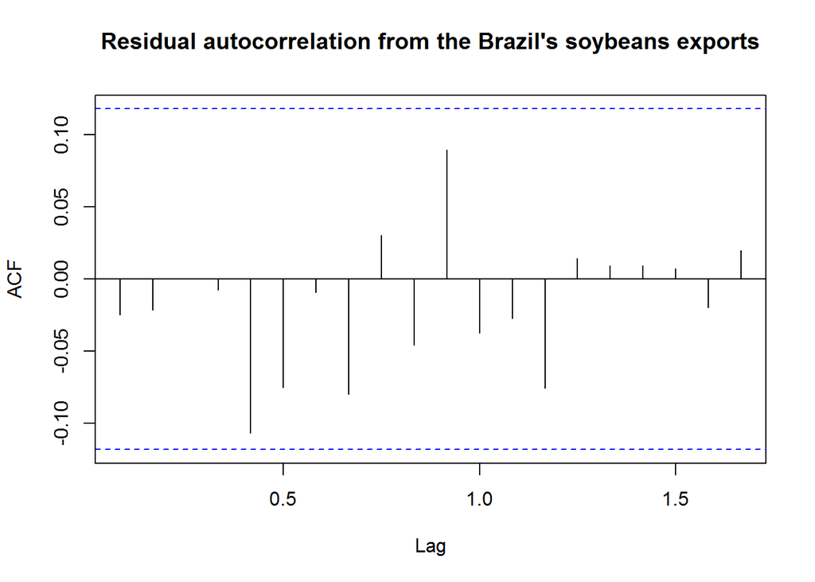

```r
# HO: No autocorrelation; H1: There's autocorrelation
Acf(sbARMA$residuals,lag.max = 20,type = "correlation",plot = TRUE, na.action = na.omit, main = "Residual autocorrelation from the Brazil's soybeans exports")
```

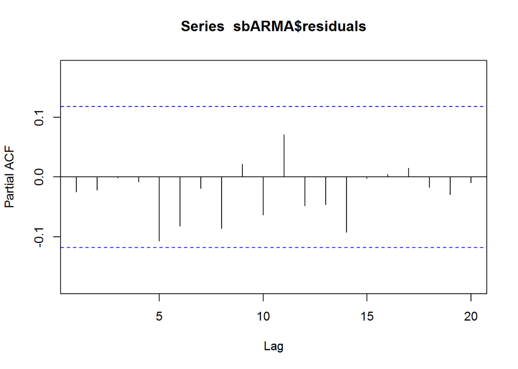

```r
Pacf(x = sbARMA$residuals,lag.max = 20,plot = TRUE)
```

```r
# Variance Stationarity Test
ArchTest(x = sbARMA$residuals^2, lags = 20)
```

```
##
##  ARCH LM-test; Null hypothesis: no ARCH effects
##
## data:  sbARMA$residuals^2
## Chi-squared = 7.4286, df = 20, p-value = 0.995
```

```r
# HO: No ARCH effects; H1: There's ARCH effect

# Residual Normality Test
jb.norm.test(na.omit(sbARMA$residuals), nrepl = 1000)
```

```
##
##  Jarque-Bera test for normality
##
## data:  na.omit(sbARMA$residuals)
## JB = 315.41, p-value < 2.2e-16
```

```r
# HO: Normality; H1: No normality
```

```r
#### Soybeans Meal - Model Diagnostic ####

# Residual Autocorrelation Test
Box.test(x = sbm_ARMA$residuals, lag = 20, type = "Ljung-Box", fitdf = 5)
```

```
##
##  Box-Ljung test
##
## data:  sbm_ARMA$residuals
## X-squared = 82.788, df = 15, p-value = 2.152e-11
```

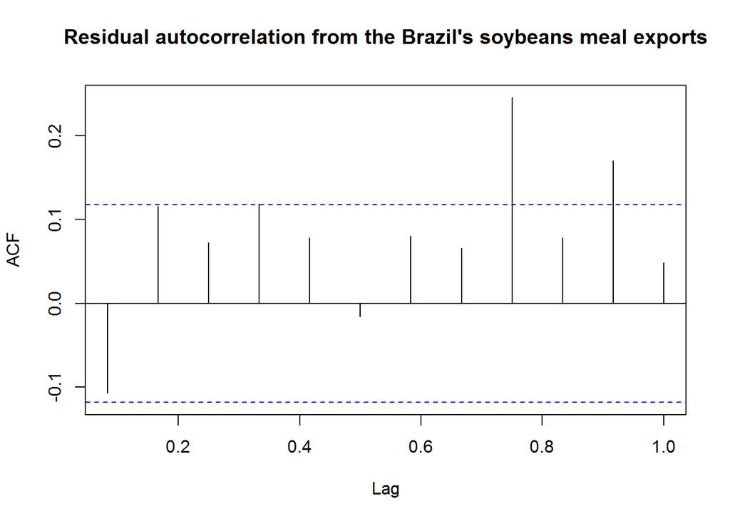

```r
# HO: No autocorrelation; H1: There's autocorrelation
Acf(sbm_ARMA$residuals,lag.max = 12,type = "correlation",plot = TRUE, na.action = na.omit, main = "Residual autocorrelation from the Brazil's soybeans meal exports")
```